# Statistical Computing with R (Due to Nov.29th)

## 200903877 황성윤

## Department of Statistics

### Assignment

- UCI(Univ. of California, Inrvine)의 machine learning repository에 가면 많은 분석용 데이터가 있습니다.
- 이 중 wine quality data ( http://archive.ics.uci.edu/ml/datasets/Wine+Quality)라고 있는데… 이 데이터로 ggplot2를 이용한 아름다운 그림을 그려 보세요.
- 피겨 스케이팅 시 기본 점수에서는 각종 난이도에 해당하는 기술이 펼쳐져야 하는 만큼 다음과 같은 그래프가 반드시 포함되어야 합니다.
- bar chart, scatter plot, histogram, stacked chart, pie chart, rose chart 그리고 facet 적용!!
- 재미있는 이야기 ggplot2로 재미있는 그림책 같은 이야기 만들어 보길 바랍니다.

### Fasten your seat belt. Get ready? Start !!

먼저 필요한 패키지들을 열고 그림을 그리는 데 사용할 데이터를 불러들이도록 하겠다.

```r
library(UsingR)
```

```r
library(knitr)
library(lattice)
library(ggplot2)
redwine <- read.csv("D:/수업자료/(2)Sophomore/2-2/통계계산및실습(1전공)/과제/winequality-red.csv",
    sep = ";", header = T)
whitewine <- read.csv("D:/수업자료/(2)Sophomore/2-2/통계계산및실습(1전공)/과제/winequality-white.csv",
    sep = ";", header = T)
```

redwine과 whitewine 이 두가지 데이터에는 빨간색 와인과 흰색 와인에 대한 여러가지 정보들이 들어있다. 이 데이터에 나와있는 요소들을 번역해보면 다음과 같다. fixed acidity : 고유산성 volatile acidity : 휘발성 citric acid : 구연산 residual sugar : 잔여설탕 chlorides : 염화물 free sulfur dioxide : 아황산가스 total sulfur dioxide : 총 아황산가스 density : 밀도 pH : 산성도 sulphates : 황산염 alcohol : 알코올 quality : 와인의 질

많은 이들이 아마도 빨간색 와인과 흰색 와인이 과연 어떠한 특징과 차이가 있는지 궁금해할 것이라고 생각한다. 그래서 그래프를 번갈아 그려가면서 이러한 것들을 알아보고자 한다.

#### 1. 밀도와 산성도에 따른 와인의 상태?

먼저 각각의 와인에 대하여 밀도와 산성도에 관한 그래프를 그려보도록 하자.

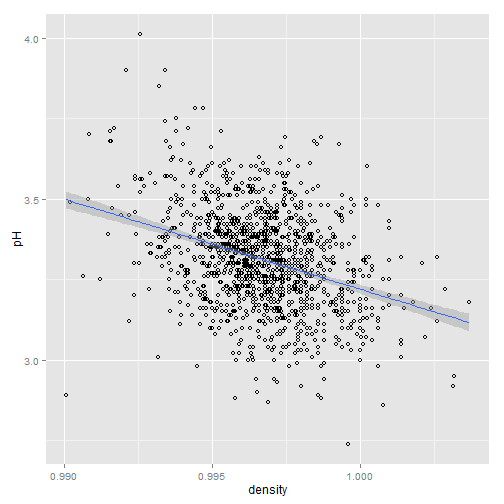

```r
ggplot(redwine, aes(x = density, y = pH)) + geom_point(shape = 1) + geom_smooth(method = lm)
```

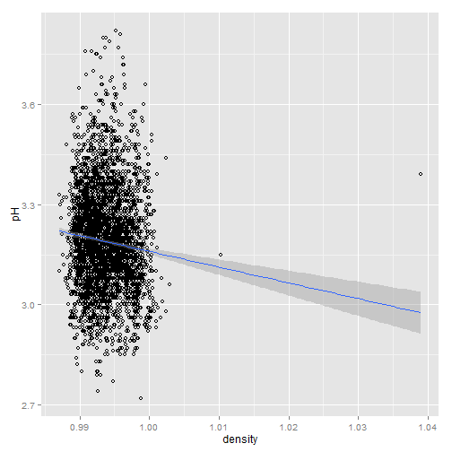

```r
ggplot(whitewine, aes(x = density, y = pH)) + geom_point(shape = 1) + geom_smooth(method = lm)
```

이 두 그림을 살펴보자. 빨간색 와인과 흰색 와인 모두 밀도와 산성도가 크게 퍼져있지 않고 한 곳에 집중되어 있는 것으로 보인다. 굳이 차이점을 찾아보라고 한다면 흰색 와인의 경우 밀도가 드러나게 크게 나타나는 두개의 특이점이 존재한다고 얘기할 수 있겠다. 그렇다면 이 밀도와 산성도에 따라서 와인의 질이 달라질 수 있지 않을까? 다시 그래프를 그려보도록 하자.

먼저 빨간색 와인에 대한 두 그래프이다.

```
## stat_bin: binwidth defaulted to range/30. Use 'binwidth = x' to adjust
## this.
```

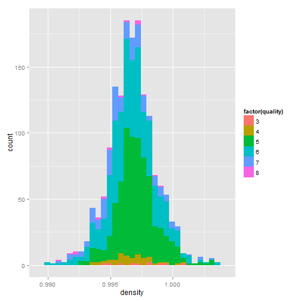

```r
ggplot(redwine, aes(density, fill = factor(quality))) + geom_histogram()
```

```
## stat_bin: binwidth defaulted to range/30. Use 'binwidth = x' to adjust
## this.
```

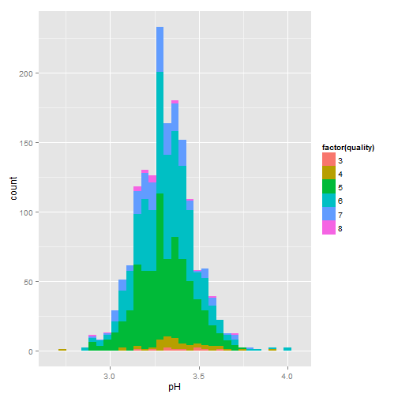

```r
ggplot(redwine, aes(pH, fill = factor(quality))) + geom_histogram()
```

이제 흰색 와인에 대해서도 그려보자.

```
## stat_bin: binwidth defaulted to range/30. Use 'binwidth = x' to adjust
## this.
```

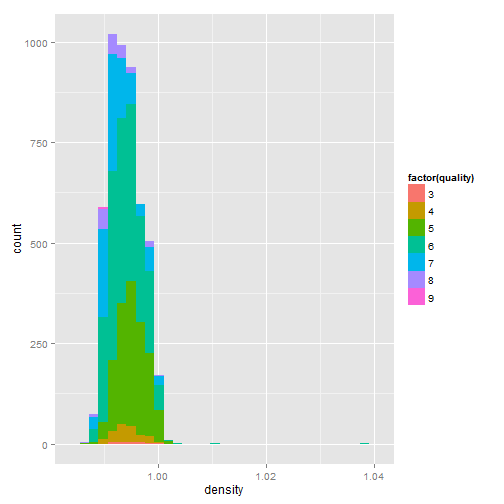

```r
ggplot(whitewine, aes(density, fill = factor(quality))) + geom_histogram()
```

```
## stat_bin: binwidth defaulted to range/30. Use 'binwidth = x' to adjust
## this.
```

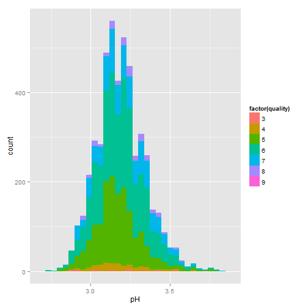

```r
ggplot(whitewine, aes(pH, fill = factor(quality))) + geom_histogram()
```

#### 2. 휘발성과 알코올, 그리고 구연산과의 관계?

일단 와인에도 술과 마찬가지로 알코올이 들어가기 때문에 휘발성을 빼놓고 넘어갈 수 없을 것 같다. 그러면 먼저 각각의 와인에 대해 와인의 상태가 어떤 분포를 나타내는지 그림을 통해 알아보도록 하자.

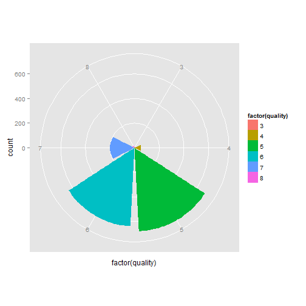

```r
ggplot(redwine, aes(factor(quality), fill = factor(quality))) + geom_bar() +
    coord_polar()
```

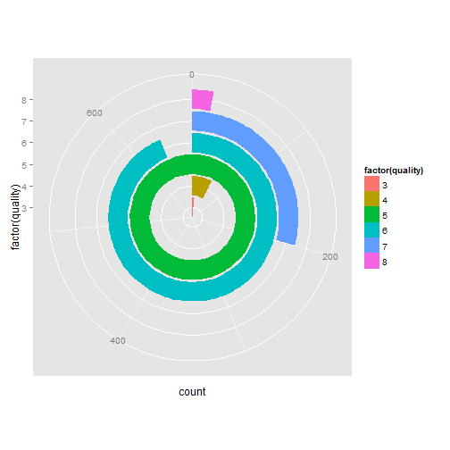

```r
ggplot(redwine, aes(factor(quality), fill = factor(quality))) + geom_bar() +
    coord_polar(theta = "y")
```

일단 빨간색 와인은 상태의 수준이 5와 6 그리고 7에서 많이 분포하는 것으로 보여진다.

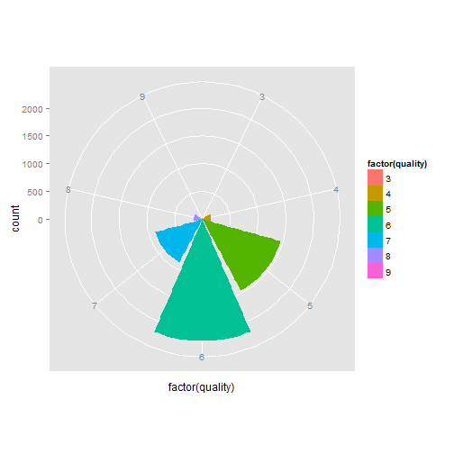

```r
ggplot(whitewine, aes(factor(quality), fill = factor(quality))) + geom_bar() +
    coord_polar()
```

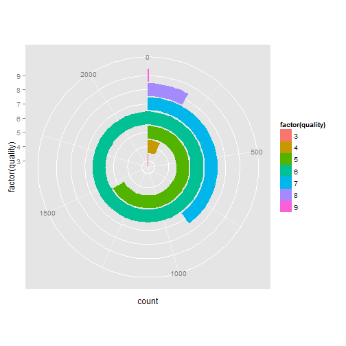

```r
ggplot(whitewine, aes(factor(quality), fill = factor(quality))) + geom_bar() +
    coord_polar(theta = "y")
```

흰색 와인도 빨간색의 경우와 마찬가지 경향을 보이고 있다.

이제 휘발성과 알코올의 상관관계가 어느 정도인지 알아보도록 하자.

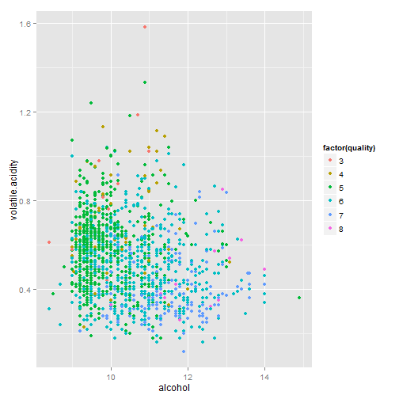

```r
ggplot(redwine, aes(alcohol, volatile.acidity)) + geom_point(aes(colour = factor(quality)))
```

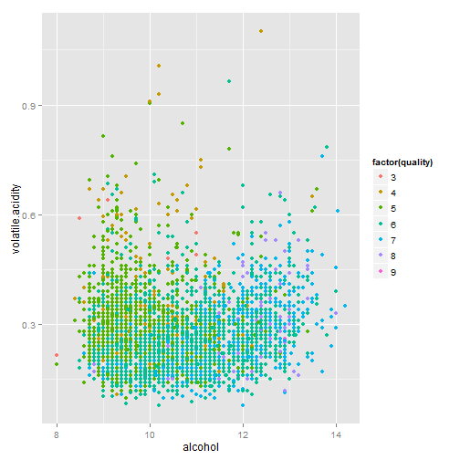

```r
ggplot(whitewine, aes(alcohol, volatile.acidity)) + geom_point(aes(colour = factor(quality)))
```

이 그림을 보면 알코올과 휘발성이 양의 상관관계를 가지고 있다고 자신있게 주장하는 것에는 무리가 있다고 보여진다. 직관적으로 양의 상관관계가 있을거라고 추측하는 사람들이 대다수일거라 여겨지는데 결과는 전혀 다르게 나타나고 있다. 재미있는 사실이다. 그렇다면 구연산의 경우는 어떠할까? 먼저 구연산에 대해서 그림을 그려보고 그 다음에 관계를 살펴보도록 하자.

[output not shown]

[output not shown]

[output not shown]

[output not shown]

[output not shown]

```
## stat_bin: binwidth defaulted to range/30. Use 'binwidth = x' to adjust
## this.
```

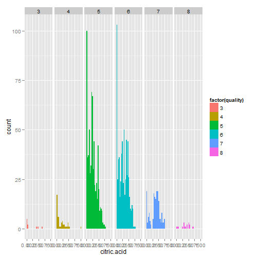

```r
ggplot(redwine, aes(citric.acid, fill = factor(quality))) + geom_bar() + facet_grid(. ~
    quality)
```

[output not shown]

[output not shown]

[output not shown]

[output not shown]

[output not shown]

[output not shown]

```
## stat_bin: binwidth defaulted to range/30. Use 'binwidth = x' to adjust
## this.
```

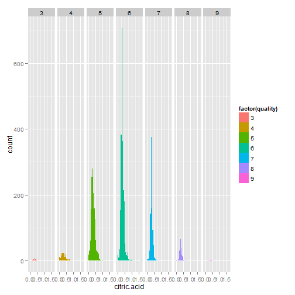

```r
ggplot(whitewine, aes(citric.acid, fill = factor(quality))) + geom_bar() + facet_grid(. ~
    quality)
```

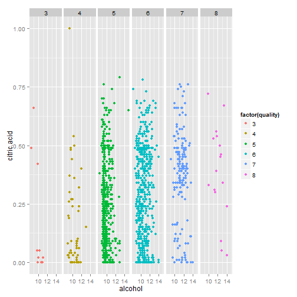

```r
ggplot(redwine, aes(alcohol, citric.acid)) + geom_point(width = 1, aes(colour = factor(quality))) +
    facet_grid(. ~ quality)
```

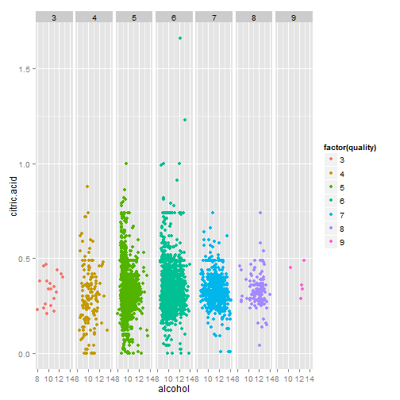

```r
ggplot(whitewine, aes(alcohol, citric.acid)) + geom_point(width = 1, aes(colour = factor(quality))) +
    facet_grid(. ~ quality)
```

이 경우도 그닥 강한 상관관계가 드러나고 있지는 않아보인다.

#### 3. 와인에 포함된 염화물에 관한 간단한 분석

한가지 흥미로운 것은 와인 속에 우리가 미처 모르고 있던 염화물이 포함되어 있다는 사실이다. 여기서는 간단히 stacked chart를 이용해 두 와인의 경우 각각의 염화물의 분포형태만 살펴보도록 하자.

(1) red wine

```
## stat_bin: binwidth defaulted to range/30. Use 'binwidth = x' to adjust
## this.
```

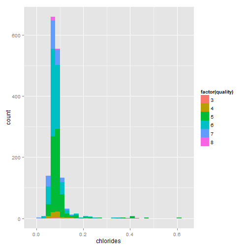

```r
qplot(chlorides, data = redwine, geom = "histogram", fill = factor(quality),
    position = "stack")
```

```
## stat_bin: binwidth defaulted to range/30. Use 'binwidth = x' to adjust
## this.
```

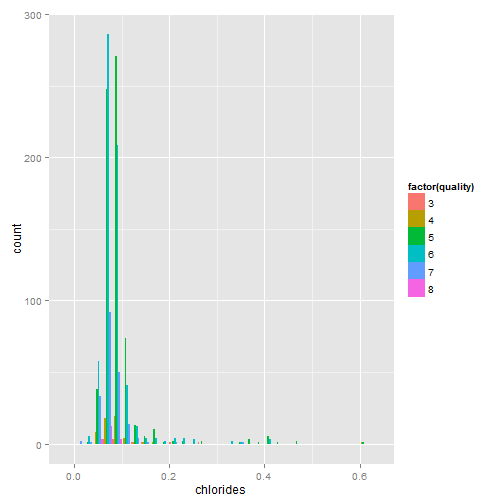

```r
qplot(chlorides, data = redwine, geom = "histogram", fill = factor(quality),
    position = "dodge")
```

```
## stat_bin: binwidth defaulted to range/30. Use 'binwidth = x' to adjust
## this.
```

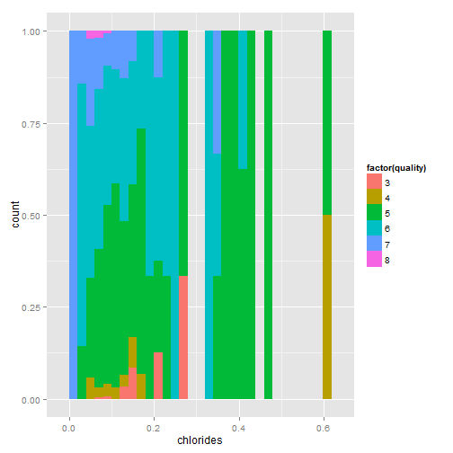

```r
qplot(chlorides, data = redwine, geom = "histogram", fill = factor(quality),
    position = "fill")
```

```
## stat_bin: binwidth defaulted to range/30. Use 'binwidth = x' to adjust
## this.
```

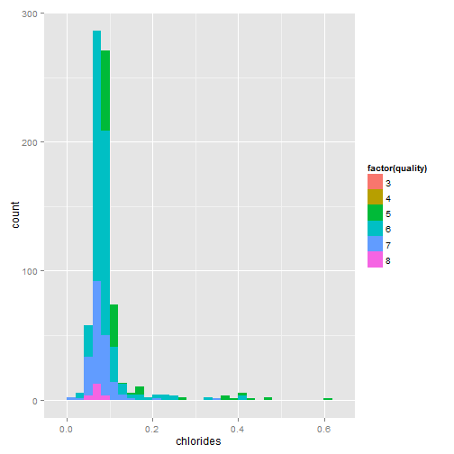

```r
qplot(chlorides, data = redwine, geom = "histogram", fill = factor(quality),
    position = "identity")
```

```
## stat_bin: binwidth defaulted to range/30. Use 'binwidth = x' to adjust
## this.
```

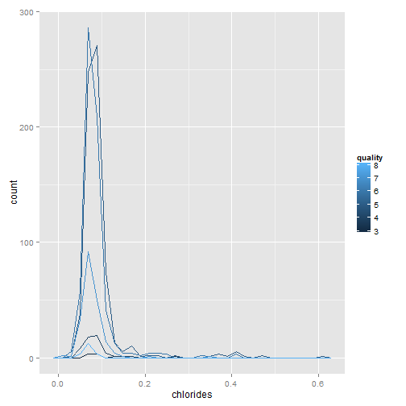

```r
qplot(chlorides, data = redwine, geom = "freqpoly", group = quality, colour = quality,
    position = "identity")
```

```
## stat_bin: binwidth defaulted to range/30. Use 'binwidth = x' to adjust
## this.
```

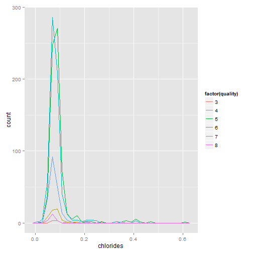

```r
qplot(chlorides, data = redwine, geom = "freqpoly", group = factor(quality),
    colour = factor(quality), position = "identity")
```

```
## stat_bin: binwidth defaulted to range/30. Use 'binwidth = x' to adjust
## this.
```

```
## ymax not defined: adjusting position using y instead
```

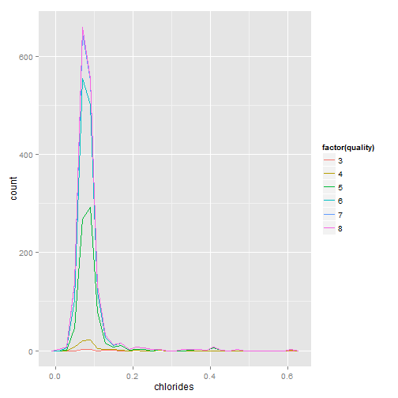

```r
qplot(chlorides, data = redwine, geom = "freqpoly", group = factor(quality),
    colour = factor(quality), position = "stack")
```

(2) white wine

```
## stat_bin: binwidth defaulted to range/30. Use 'binwidth = x' to adjust
## this.
```

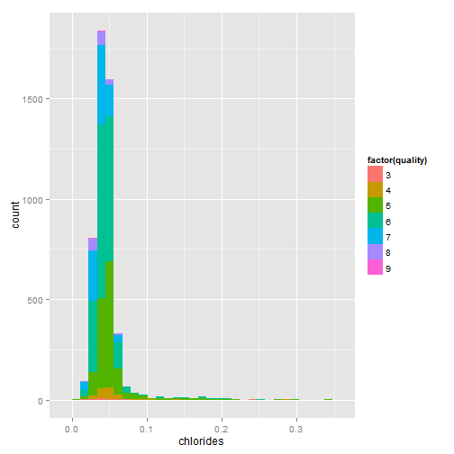

```r
qplot(chlorides, data = whitewine, geom = "histogram", fill = factor(quality),
    position = "stack")
```

```
## stat_bin: binwidth defaulted to range/30. Use 'binwidth = x' to adjust
## this.
```

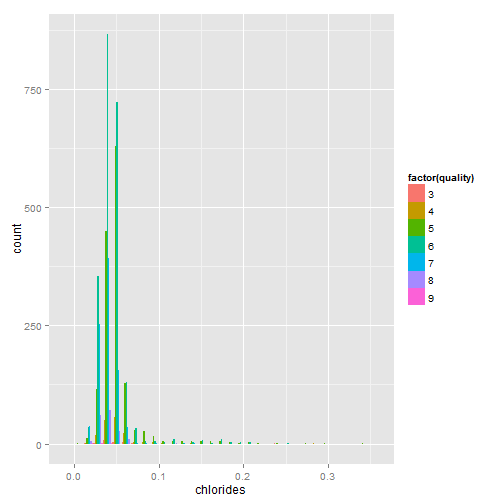

```r
qplot(chlorides, data = whitewine, geom = "histogram", fill = factor(quality),
    position = "dodge")
```

```
## stat_bin: binwidth defaulted to range/30. Use 'binwidth = x' to adjust
## this.
```

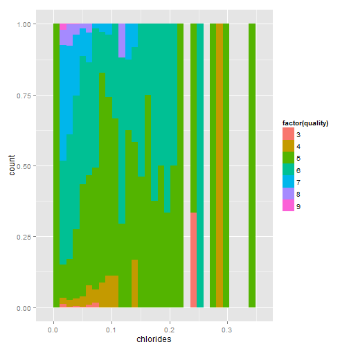

```r
qplot(chlorides, data = whitewine, geom = "histogram", fill = factor(quality),
    position = "fill")
```

```
## stat_bin: binwidth defaulted to range/30. Use 'binwidth = x' to adjust
## this.
```

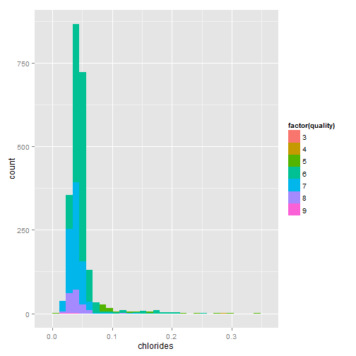

```r
qplot(chlorides, data = whitewine, geom = "histogram", fill = factor(quality),
    position = "identity")
```

```
## stat_bin: binwidth defaulted to range/30. Use 'binwidth = x' to adjust
## this.
```

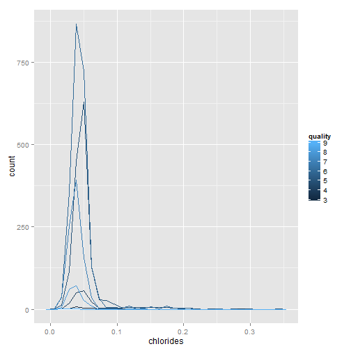

```r
qplot(chlorides, data = whitewine, geom = "freqpoly", group = quality, colour = quality,
    position = "identity")
```

```
## stat_bin: binwidth defaulted to range/30. Use 'binwidth = x' to adjust
## this.
```

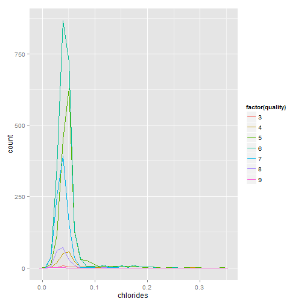

```r
qplot(chlorides, data = whitewine, geom = "freqpoly", group = factor(quality),
    colour = factor(quality), position = "identity")
```

```
## stat_bin: binwidth defaulted to range/30. Use 'binwidth = x' to adjust
## this.
```

```
## ymax not defined: adjusting position using y instead
```

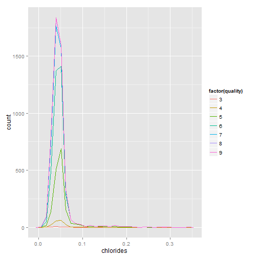

```r
qplot(chlorides, data = whitewine, geom = "freqpoly", group = factor(quality),
    colour = factor(quality), position = "stack")
```